# anova analysis

```r
setwd('C:/Users/Elena/Desktop/Elena/Polimi/MAGISTRALE/Nonparametric statistics/Progetto/github repository/ALZHEIMER_prognonpa/Elena')
dataset_xsectional <- read.csv("oasis_cross-sectional.csv", header = T)
dataset_longitudinal <- read.csv("oasis_longitudinal.csv", header = T)
```

We are interested in the importance of variables sex and age in the prediction of the state of the patient (if demented or not). So we can start analyzing these two variables wrt the grouping: sex and age can be thought as categorical and we use CDR as dependent variable.

Check for only the **FIRST** visit of each patient to have independence

```r
data11 <- dataset_longitudinal[which(dataset_longitudinal$Visit == 1),]
data11 <- data.frame(as.factor(data11$M.F), as.factor(data11$Age), data11$CDR)
colnames(data11) <- c('M.F','Age','CDR')
```

```r
anova12 <- aov(CDR~M.F, data=data11)
summary(anova12)
```

```
             Df Sum Sq Mean Sq F value Pr(>F)
M.F           1  0.655  0.6547   6.373 0.0126 *
Residuals   148 15.205  0.1027
---
Signif. codes:  0 ‘***’ 0.001 ‘**’ 0.01 ‘*’ 0.05 ‘.’ 0.1 ‘ ’ 1
```

```r
shapiro.test(anova12$residuals)
```

```
    Shapiro-Wilk normality test

data:  anova12$residuals
W = 0.83063, p-value = 6.991e-12
```

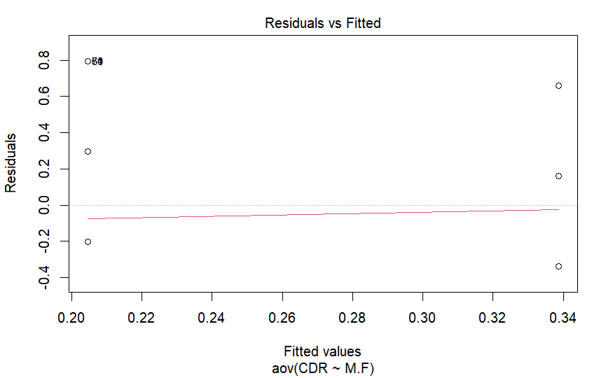

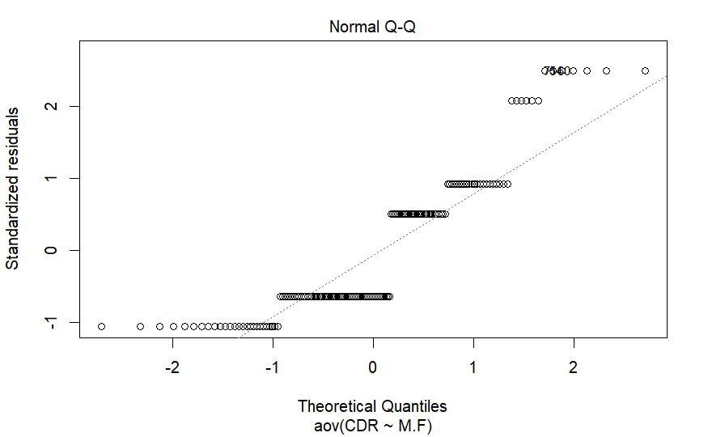

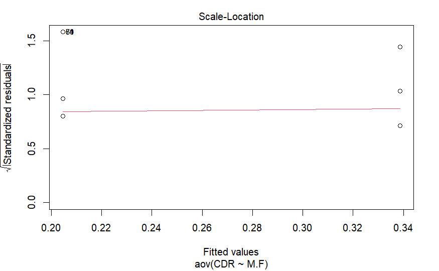

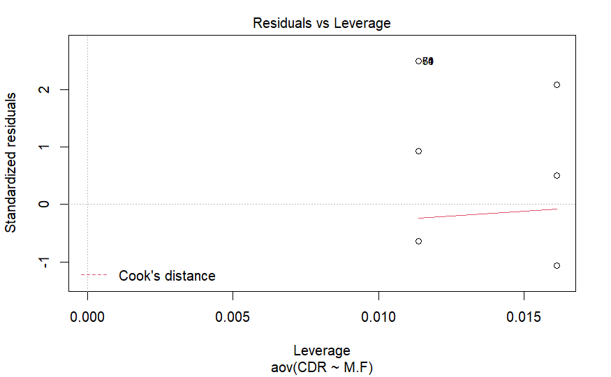

```r
plot(anova12)
```

since we cannot assume normality of residuals (pvalue very low) we should use a nonparametric test (ex kruskal wallis)

```r
kw11 <- kruskal.test(CDR~M.F, data=data11)
kw11
```

```
    Kruskal-Wallis rank sum test

data:  CDR by M.F
Kruskal-Wallis chi-squared = 7.8355, df = 1, p-value = 0.005123
```

hence the sex is significant